# CSCI E-106: Section 02

# 1.20. Copier maintenance.

## #Loading Data

```r
# Assigning the data to a data frame object
# called df20 and then we want to name the columns
df20 = read.delim("/cloud/project/Fall 2020/CH01PR20.txt", header=FALSE, sep="")
colnames(df20) = c("y", "x")
```

## a. Obtain the estimated regression function.

### Solution

```r
lmFit20 = lm(y~x, df20)
print(summary(lmFit20))
```

```
##
## Call:
## lm(formula = y ~ x, data = df20)
##
## Residuals:
##      Min       1Q   Median       3Q      Max
## -22.7723  -3.7371   0.3334   6.3334  15.4039
##
## Coefficients:
##             Estimate Std. Error t value Pr(>|t|)
## (Intercept)  -0.5802     2.8039  -0.207    0.837
## x            15.0352     0.4831  31.123   <2e-16 ***
## ---
## Signif. codes:  0 '***' 0.001 '**' 0.01 '*' 0.05 '.' 0.1 ' ' 1
##
## Residual standard error: 8.914 on 43 degrees of freedom
## Multiple R-squared:  0.9575, Adjusted R-squared:  0.9565
## F-statistic: 968.7 on 1 and 43 DF,  p-value: < 2.2e-16
```

We see that to obtain our estimated regression function we would use the estimate column values so our answer would become: -.5802 + 15.0352x

## b. Plot the estimated regression function and the data. How well does the estimated regression function fit the data?

### Solution

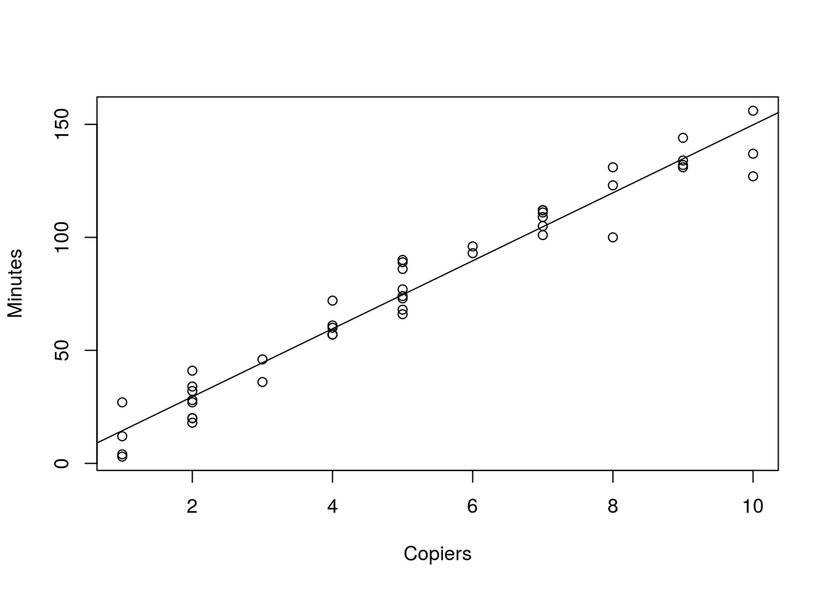

```r
plot(df20$x, df20$y, xlab="Copiers", ylab="Minutes")
abline(lmFit20)
```

By just looking at our data we do have a well fit line here.

## c. Interpret $b_o$ in your estimated regression function. Does $b_o$ provide any relevant information here? Explain.

### Solution

```r
yHat = predict(lmFit20, data.frame(x=0))
print(yHat)
```

```
##          1
## -0.5801567
```

$b_0$ does not give us any sensible information since the predicted value is a negative number

## d. Obtain a point estimate of the mean service time when $X = 5$ copiers are serviced.

### Solution

```r
yHat = predict(lmFit20, data.frame(x=5))
print(yHat)
```

```
##        1
## 74.59608
```

# 1.21. Airfreight breakage.

## #Loading Data

```r
df21 = read.delim("/cloud/project/Fall 2020/CH01PR21.txt", header=FALSE, sep="")
# df21_1 = read.table("CH01PR21.txt")
colnames(df21) = c("y", "x")
```

## a. Obtain the estimated regression function. Plot the estimated regression function and the data. Does a linear regression function appear to give a good fit here?

### Solution

```r
lmFit21 = lm(y~x, df21)
print(summary(lmFit21))
```

```
##
## Call:
## lm(formula = y ~ x, data = df21)
##
## Residuals:
##    Min     1Q Median     3Q    Max
##   -2.2   -1.2    0.3    0.8    1.8
##
## Coefficients:
##             Estimate Std. Error t value Pr(>|t|)
## (Intercept)  10.2000     0.6633  15.377 3.18e-07 ***
## x             4.0000     0.4690   8.528 2.75e-05 ***
## ---
## Signif. codes:  0 '***' 0.001 '**' 0.01 '*' 0.05 '.' 0.1 ' ' 1
##
## Residual standard error: 1.483 on 8 degrees of freedom
## Multiple R-squared:  0.9009, Adjusted R-squared:  0.8885
## F-statistic: 72.73 on 1 and 8 DF,  p-value: 2.749e-05
```

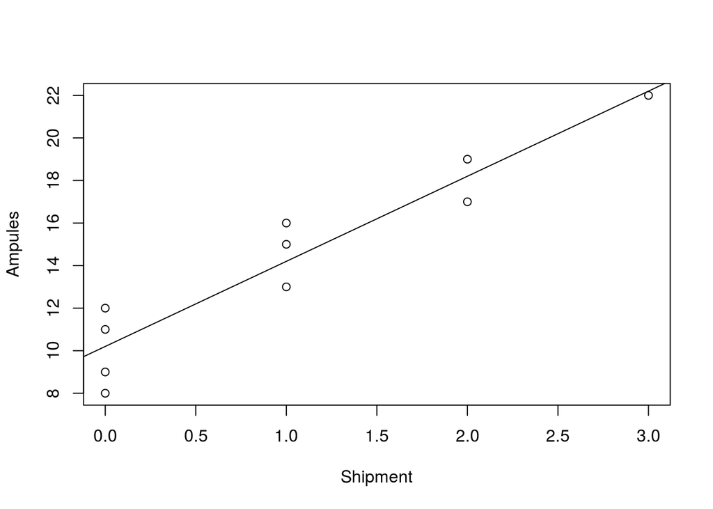

```r
plot(df21$x, df21$y, xlab="Shipment", ylab="Ampules")
abline(lmFit21)
```

We see that our regression function is $y = 10.2 + 4.0 x$

## b. Obtain a point estimate of the expected number of broken ampules when $X = 1$ transfer is made.

### Solution

```r
yHat1 = predict(lmFit21, data.frame(x=1))
print(yHat1)
```

```
##    1
## 14.2
```

## c. Estimate the increase in the expected number of ampules broken when there are 2 transfers as compared to 1 transfer.

### Solution

```r
yHat2 = predict(lmFit21, data.frame(x=2))
print(yHat1) #value when x = 1
```

```
##    1
## 14.2
```

```r
print(yHat2) #value when x = 2
```

```
##    1
## 18.2
```

```r
print(yHat2 - yHat1)
```

```
## 1
## 4
```

## d. Verify that your fitted regression line goes through the point ($\bar{X}$, $\bar{Y}$).

### Solution

```r
meanX = mean(df21$x)
meanY = mean(df21$y)

# Same thing, different notation
apply(df21, 2, mean)
```

```
##    y    x
## 14.2  1.0
```

```r
print("xbar: ", meanX)
```

```
## [1] "xbar: "
```

```r
print("ybar: ", meanY)
```

```
## [1] "ybar: "
```

```r
print(predict(lmFit21, data.frame(x=meanX)))
```

```
##    1
## 14.2
```

```r
#or we can simply look at the fitted data by using the Fitted Function
fitted(lmFit21)
```

```
##    1    2    3    4    5    6    7    8    9   10
## 14.2 10.2 18.2 10.2 22.2 14.2 10.2 14.2 18.2 10.2
```

# 1.24. Refer to *Copier maintenance* Problem 1.20.

## a Obtain the residuals $e_i$ and the sum of the squared residuals $\sum{e}_i^2$. What is the relation between the sum of the squared residuals here and the quantity Q in (1.8)?

### Solution

```r
yHat = predict(lmFit20)

resids = (df20$y - yHat)
print(resids)
```

```
##           1           2           3           4           5           6
##  -9.4903394   0.4391645   1.4744125  11.5096606  -2.4550914 -12.7723238
##           7           8           9          10          11          12
##  -6.5960836  14.4039164 -10.4550914   2.5096606   9.2629243   6.2276762
##          13          14          15          16          17          18
##   3.3686684  -8.5255875  12.4391645 -19.7018277   0.3334204  11.2981723
##          19          20          21          22          23          24
## -22.7723238  -2.5608355  -8.5960836  -3.6665796   4.3334204  -0.5960836
##          25          26          27          28          29          30
##  -0.7370757   7.3334204 -11.4903394  -1.5960836   6.3334204   6.3686684
##          31          32          33          34          35          36
##   3.2981723  15.4039164  -9.4903394  -1.4903394 -11.4550914  -2.5608355
##          37          38          39          40          41          42
##  11.4039164  -2.7370757   7.3334204  12.5449086  -3.7370757   4.5096606
##          43          44          45
##  -2.4903394   1.4391645   2.4039164
```

```r
# Same thing, different syntax
# resids = lmFit20$residuals
# print(resids)

#Sum of the squared residuals
SSE = (sum(resids^2))
print(SSE)
```

```
## [1] 3416.377
```

## b. Obtain point estimates of $\sigma^2$ and $\sigma$. In what units is $\sigma$ expressed?

### Solution

```r
# Degrees of freedom residual
dfResid = lmFit20$df.residual
MSE = (SSE/dfResid)
print(MSE)
```

```
## [1] 79.45063
```

```r
# Obtain original units
sqrt(MSE)
```

```
## [1] 8.913508
```

```r
# We can also see sigma ^2 by using the anova function
anova(lmFit20)
```

|  | Df | Sum Sq | Mean Sq | F value | Pr(>F) |
| --- | --- | --- | --- | --- | --- |
| x | 1 | 76960.423 | 76960.42298 | 968.6572 | 4.009032e-31 |
| Residuals | 43 | 3416.377 | 79.45063 | NA | NA |

```r
#mean is expressed in the units of minutes.
```

# 1.25. Refer to *Airfreight breakage* Problem 1.21.

## a. Obtain the residual for the first case. What is its relation to $\epsilon_i$?

### Solution

```r
yHat = predict(lmFit21)

resids = (df21$y - yHat)

# Same thing, different syntax
# resids = lmFit21$residuals
# print(resids)

print(resids[1])
```

```
##   1
## 1.8
```

## b. Compute $\sum{e}_i^2$ and $MSE$. What is estimated by $MSE$?

### Solution

```r
SSE = (sum(resids^2))

# Degrees of freedom residual
dfResid = lmFit21$df.residual

MSE = (SSE/dfResid)
print(MSE)
```

```
## [1] 2.2
```

```r
# To obtain original units, take the sqrt
# sqrt(MSE)
```

# 1.27. Muscle mass.

## #Loading Data

```r
df27 = read.delim("CH01PR27.txt", header=FALSE, sep="")
colnames(df27) = c("y", "x")
```

## a. Obtain the estimated regression function. Plot the estimated regression function and the data. Does a linear regression function appear to give a good fit here? Does your plot support the anticipation that muscle mass decreases with age?

### Solution

```r
lmFit27 = lm(y~x, df27)
print(summary(lmFit27))
```

```
##
## Call:
## lm(formula = y ~ x, data = df27)
##
## Residuals:
##      Min       1Q   Median       3Q      Max
## -16.1368  -6.1968  -0.5969   6.7607  23.4731
##
## Coefficients:
##             Estimate Std. Error t value Pr(>|t|)
## (Intercept) 156.3466     5.5123   28.36   <2e-16 ***
## x            -1.1900     0.0902  -13.19   <2e-16 ***
## ---
## Signif. codes:  0 '***' 0.001 '**' 0.01 '*' 0.05 '.' 0.1 ' ' 1
##
## Residual standard error: 8.173 on 58 degrees of freedom
## Multiple R-squared:  0.7501, Adjusted R-squared:  0.7458
## F-statistic: 174.1 on 1 and 58 DF,  p-value: < 2.2e-16
```

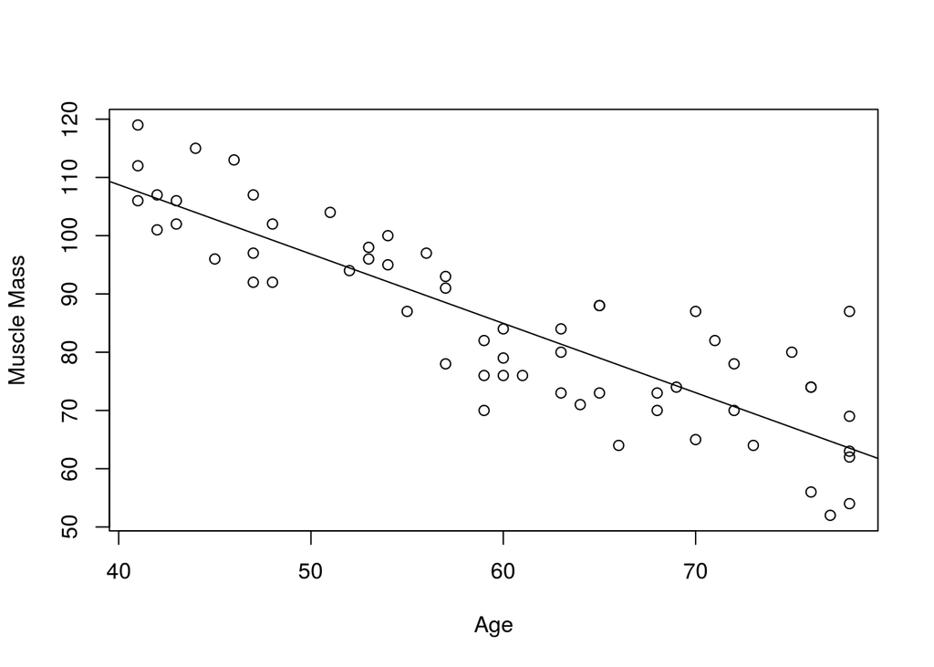

```r
plot(df27$x, df27$y, xlab="Age", ylab="Muscle Mass")
abline(lmFit27)
```

So $y = 156.34 - 1.19x$ Assessing the plot, it does appear to support the anticipation that muscle mass decreases with age.

## b. Obtain the following: (1) a point estimate of the difference in the mean muscle mass for women differing in age by one year, (2) a point estimate of the mean muscle mass for women aged $X =60$ years, (3) the value of the residual for the eighth case, (4) a point estimate of $\sigma^2$.

### Solution

```r
# 1
beta1 = lmFit27$coefficients[2]
print(beta1)
```

```
##         x
## -1.189996
```

```r
# 2
yHat = predict(lmFit27, data.frame(x=60))
print(yHat)
```

```
##        1
## 84.94683
```

```r
# 3
yHat = predict(lmFit27)

resids = (df27$y - yHat)
print(resids)
```

```
##           1           2           3           4           5           6
##   0.8232429  -1.5567482  -3.4167751  11.3932294  -6.7967661  11.4432518
##           7           8           9          10          11          12
##  -8.4167751   4.4432518  -7.2267796   2.7732204   0.6332473   6.5832249
##          13          14          15          16          17          18
##  -3.1767571  11.0132384  -5.3667527  -3.8968110   2.4831800   7.2931845
##          19          20          21          22          23          24
##  -4.1368289 -10.5168200   2.9131935   4.7231980  -0.4667975   2.7231980
##          25          26          27          28          29          30
##   7.9131935  -0.9468334 -16.1368289   8.3432070 -10.1368289   4.4831800
##          31          32          33          34          35          36
##  -2.4268693  -8.3768469  -8.9468334  -1.3768469   2.6231531  -9.1868514
##          37          38          39          40          41          42
## -13.8068603   9.0031442  -5.9468334   9.0031442  -5.9968558  -0.2368738
##          43          44          45          46          47          48
##  -7.7568379  13.9531217  -5.4268693   5.4730858  -9.5269142  -1.5269142
##          49          50          51          52          53          54
##   7.3331128  -8.0468783  -5.4768917   8.0930948  23.4730858  -0.5269142
##          55          56          57          58          59          60
##  10.1431172  12.9030993 -12.7169097  -9.9069052  -0.6668872   8.0930948
```

```r
# Same thing, different syntax
# resids = lmFit27$residuals
# print(resids)

print(resids[8])
```

```
##        8
## 4.443252
```

```r
# 4
# Degrees of freedom residual
dfResid = lmFit27$df.residual
SSE = (sum(resids^2))

MSE = (SSE/dfResid)
print(MSE)
```

```
## [1] 66.80082
```

# 1.38. Airfreight Breakage.

```r
# 1
e1=df21$y-(9+3*df21$x)
Q1=sum(e1^2)
Q1
```

```
## [1] 76
```

```r
# 2
e2=df21$y-(11+5*df21$x)
Q2=sum(e2^2)
Q2
```

```
## [1] 60
```

```r
cbind(Q1,Q2,17.60)
```

```
##      Q1 Q2
## [1,] 76 60 17.6
```

```r
#Yes,least squares estimation minimizes the sum of squres of error
```